# community_analysis_prescribed-fires

T. Griffin

2024-04-23

## Goals

1. Load in phyloseq data with rooted tree.
2. Evaluate sequencing depth and remove sample.
3. Normalize the read counts between samples.
4. Calculate community dissimilarities. Numbers between 0 and 1. If 0, completely similar versus if they are 1, then they’re completely dissimilar. Sorensen: Shared Species as a binary value: Abundance-unweighted Bray-Curtis: Shared Abundant species: Abundance-weighted (Abundance-)Weighted UNIFRAC: Consider Abundant Species and where they f all on the tree
5. Visualize the community data with two unconstrained Ordinations: PCoA: Linear Method. Eigenvalue = how much variation is explained by each axis. Choose to view axis 1, 2, 3, etc. and plot them together. NMDS: Non-linear. Smush multiple Dimensions into 2 or 3 axes. Need to report Stress value (ideally <0.15).
6. Run statistics with PERMANOVA and betadispR.

I am hoping to see if burned soils causes some extremophilic bacteria to start appearing with more burning!

## Set Seed

```r
#this will set my seed again
set.seed(02262000)
```

## Load libraries

```r
#load libraries adn colors
library(tidyverse)
library(devtools)
library(phyloseq)
library(patchwork)
library(vegan)
horizon_colors <- c(
  "A horizon" = "pink",
  "B horizon" = "green",
  "E horizon" = "orange")

#colors for burn year
by_colors <- c(
  "CH" = "blue",
  "1" = "purple",
  "2" = "brown",
  "4" = "yellow")
```

## Load Data

```r
#load the rooted tree
load("/local/workdir/tag92/git_repos/comp_micro_proj/Data/03_Phylogenetic_Tree/merged_phytree_preprocessed_physeq.RData")
merged_phytree
```

```
## phyloseq-class experiment-level object
## otu_table()   OTU Table:         [ 32759 taxa and 72 samples ]
## sample_data() Sample Data:       [ 72 samples by 47 sample variables ]
## tax_table()   Taxonomy Table:    [ 32759 taxa by 9 taxonomic ranks ]
## phy_tree()    Phylogenetic Tree: [ 32759 tips and 32758 internal nodes ]
```

## Read counts

```r
# Calculate the total number of reads per sample. This will tell me how many reads were per sample and I can see any outliers
raw_TotalSeqs_df  <-
  merged_phytree %>%
  # calculate the sample read sums
  sample_sums() %>%
  data.frame()
# name the column
colnames(raw_TotalSeqs_df)[1] <- "TotalSeqs"

head(raw_TotalSeqs_df)
```

```
##             TotalSeqs
## SRR19625066     28534
## SRR19625067     28274
## SRR19625068     94876
## SRR19625069     60885
## SRR19625070     80721
## SRR19625071     53628
```

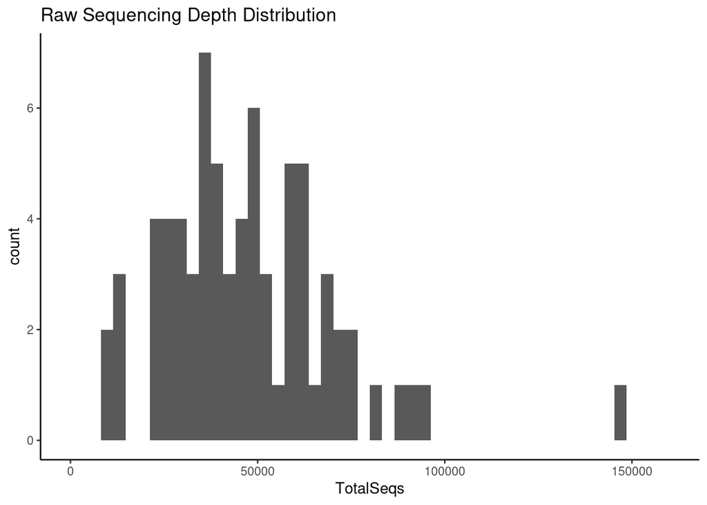

```r
#low: 10470-SRR19625128, high: 148864-SRR19625131

# make histogram of raw reads
raw_TotalSeqs_df %>%
  ggplot(aes(x = TotalSeqs)) +
  geom_histogram(bins = 50) +
  scale_x_continuous(limits = c(0, 160000)) +
  labs(title = "Raw Sequencing Depth Distribution") +
  theme_classic()
```

```r
#these did not appear strange during the phylogenetic tree generation, i do not think that i need to remove them
```

## normalize read counts

```r
#normalization makes comparisons between samples more accurate since different variables can affect read counts
matround <- function(x){trunc(x+0.5)}

scale_reads <- function(physeq, n = min(sample_sums(physeq)), round = "round") {

  # transform counts to n
  physeq.scale <- transform_sample_counts(physeq, function(x) {(n * x/sum(x))})

  # Pick the rounding functions
  if (round == "floor"){
    otu_table(physeq.scale) <- floor(otu_table(physeq.scale))
  } else if (round == "round"){
    otu_table(physeq.scale) <- round(otu_table(physeq.scale))
  } else if (round == "matround"){
    otu_table(physeq.scale) <- matround(otu_table(physeq.scale))
  }

  # Prune taxa and return new phyloseq object
  physeq.scale <- prune_taxa(taxa_sums(physeq.scale) > 1, physeq.scale)
  return(physeq.scale)
}

min(sample_sums(merged_phytree))
```

```
## [1] 10464
```

```r
#10464
```

## Scale reads and check distribution

```r
scaled_merged_phytree <-
  merged_phytree %>%
  scale_reads(round = "matround")

# Calculate the read depth
scaled_TotalSeqs_df <-
  scaled_merged_phytree %>%
  sample_sums() %>%
  data.frame()
colnames(scaled_TotalSeqs_df)[1] <-"TotalSeqs"

# Inspect
head(scaled_TotalSeqs_df)
```

```
##             TotalSeqs
## SRR19625066     10476
## SRR19625067     10466
## SRR19625068     10411
## SRR19625069     10416
## SRR19625070     10463
## SRR19625071     10462
```

```r
max(scaled_TotalSeqs_df) - min(scaled_TotalSeqs_df)
```

```
## [1] 258
```

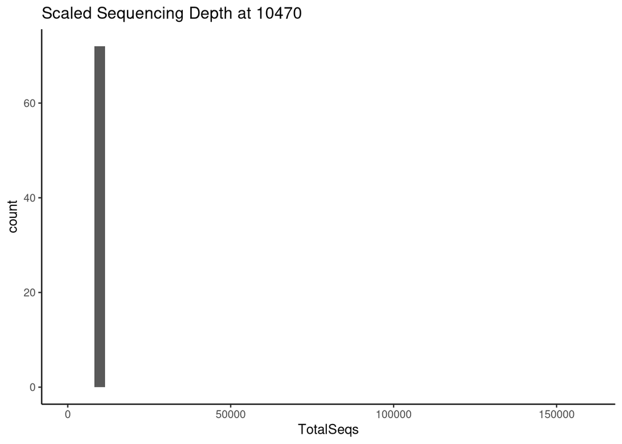

```r
scaled_TotalSeqs_df %>%
  ggplot(aes(x = TotalSeqs)) +
  geom_histogram(bins = 50) +
  scale_x_continuous(limits = c(0, 160000)) +
  labs(title = "Scaled Sequencing Depth at 10470") +
  theme_classic()
```

samples seem to be at similar range

## PCoA

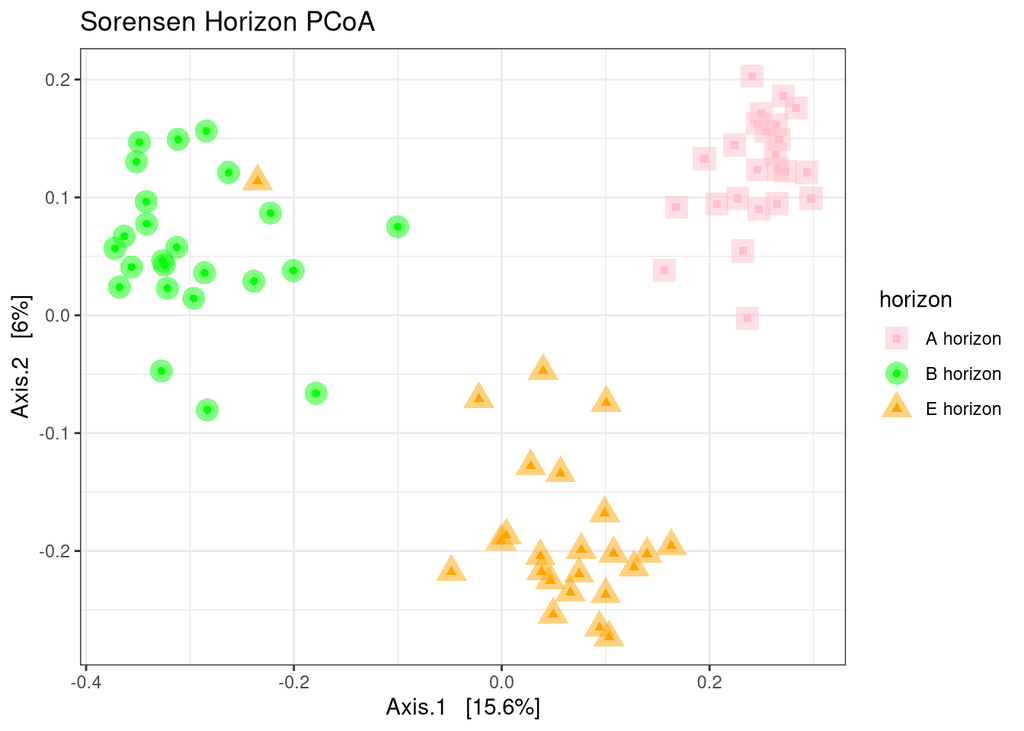

```r
# Calculate sorensen dissimilarity: Abundance-unweighted of shared taxa
scaled_soren_pcoa <-
  ordinate(
    physeq = scaled_merged_phytree,
    method = "PCoA",
    distance = "bray", binary = TRUE)

#str(scaled_soren_pcoa)

# Plot the ordination
soren_horizon_pcoa <- plot_ordination(
  physeq = scaled_merged_phytree,
  ordination = scaled_soren_pcoa,
  color = "horizon",
  shape = "horizon",
  title = "Sorensen Horizon PCoA") +
  geom_point(size=5, alpha = 0.5, aes(color = horizon)) +
  scale_shape_manual(values = c(15,16,17,18, 19, 20)) +
  scale_color_manual(values = horizon_colors) +
  theme_bw()
# Show the plot
soren_horizon_pcoa
```

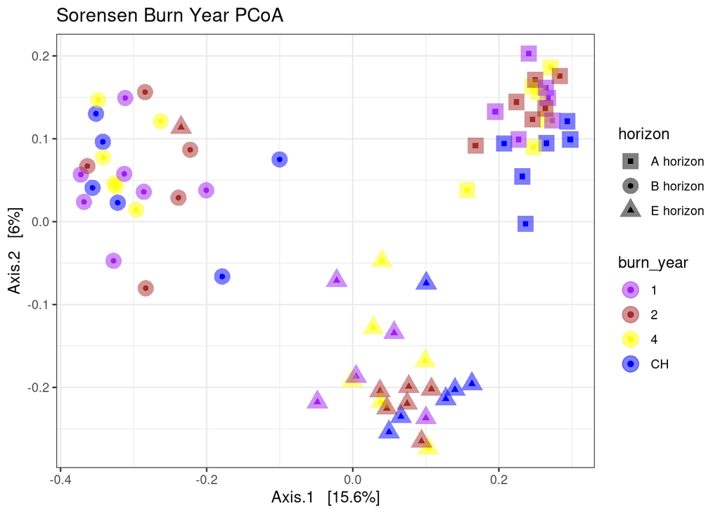

```r
#do the same thing for burn year since its working now
soren_burnyear_pcoa <- plot_ordination(
  physeq = scaled_merged_phytree,
  ordination = scaled_soren_pcoa,
  color = "burn_year",
  shape = "horizon",
  title = "Sorensen Burn Year PCoA") +
  geom_point(size=5, alpha = 0.5, aes(color = burn_year)) +
  scale_shape_manual(values = c(15,16,17,18, 19, 20)) +
  scale_color_manual(values = by_colors) +
  theme_bw()
# Show the plot
soren_burnyear_pcoa
```

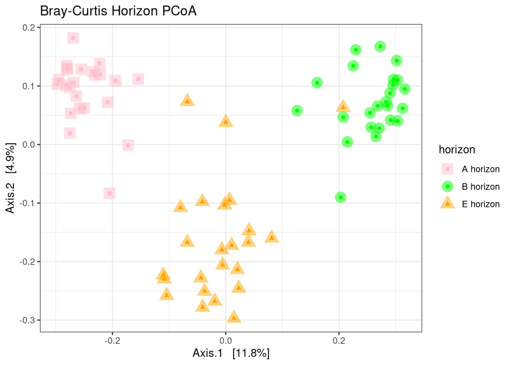

```r
# Calculate the BC distance
scaled_BC_pcoa <-
  ordinate(
    physeq = scaled_merged_phytree,
    method = "PCoA",
    distance = "bray")



# Plot the PCoA for horizons
bray_horizon_pcoa <-
  plot_ordination(
    physeq = scaled_merged_phytree,
    ordination = scaled_BC_pcoa,
    color = "horizon",
    shape = "horizon",
    title = "Bray-Curtis Horizon PCoA") +
  geom_point(size=5, alpha = 0.5, aes(color = horizon)) +
  scale_shape_manual(values = c(15,16,17,18, 19, 20)) +
  scale_color_manual(values = c(horizon_colors)) +
  theme_bw()
bray_horizon_pcoa
```

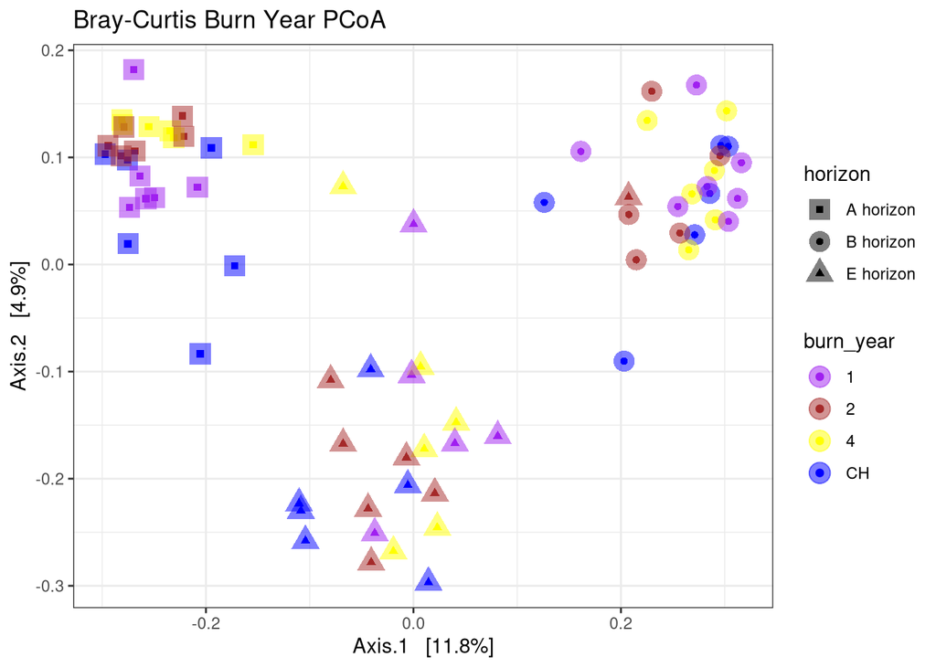

```r
#burn year
bray_burnyear_pcoa <-
  plot_ordination(
    physeq = scaled_merged_phytree,
    ordination = scaled_BC_pcoa,
    color = "burn_year",
    shape = "horizon",
    title = "Bray-Curtis Burn Year PCoA") +
  geom_point(size=5, alpha = 0.5, aes(color = burn_year)) +
  scale_shape_manual(values = c(15,16,17,18, 19, 20)) +
  scale_color_manual(values = c(by_colors)) +
  theme_bw()
bray_burnyear_pcoa
```

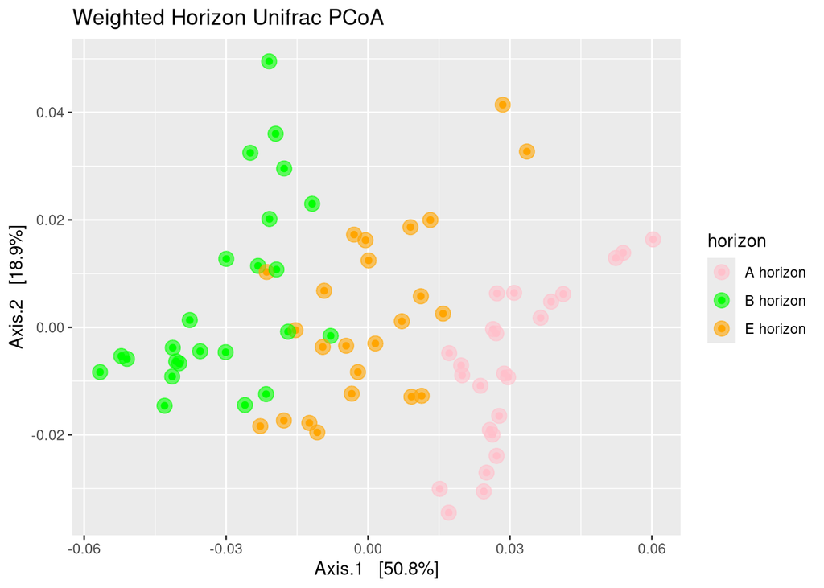

```r
unfiltered_unifrac <-
  ordinate(
    physeq=scaled_merged_phytree,
    method="PCoA",
    distance="wunifrac")
#for horizon
w_unifrac <- plot_ordination(
  physeq=scaled_merged_phytree,
  ordination=unfiltered_unifrac,
  color="horizon",
  title= "Weighted Horizon Unifrac PCoA")+
  geom_point(size=4, alpha=0.6, aes(color= horizon))+
  scale_color_manual(values=horizon_colors)
w_unifrac
```

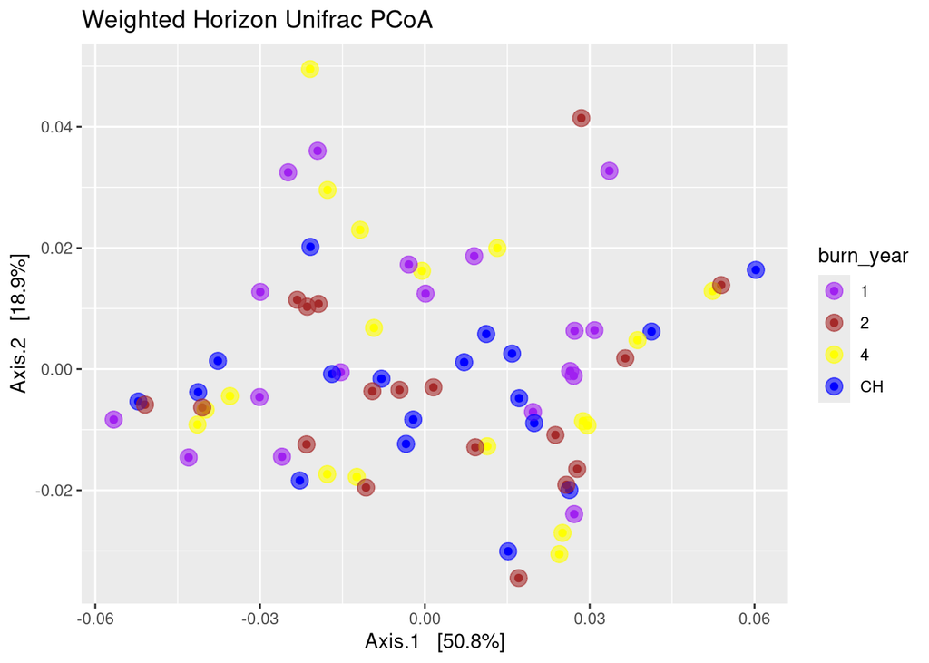

```r
#for burn year
w_unifrac_burnyear <- plot_ordination(
  physeq=scaled_merged_phytree,
  ordination=unfiltered_unifrac,
  color="burn_year",
  title= "Weighted Horizon Unifrac PCoA")+
  geom_point(size=4, alpha=0.6, aes(color= burn_year))+
  scale_color_manual(values=by_colors)
w_unifrac_burnyear
```

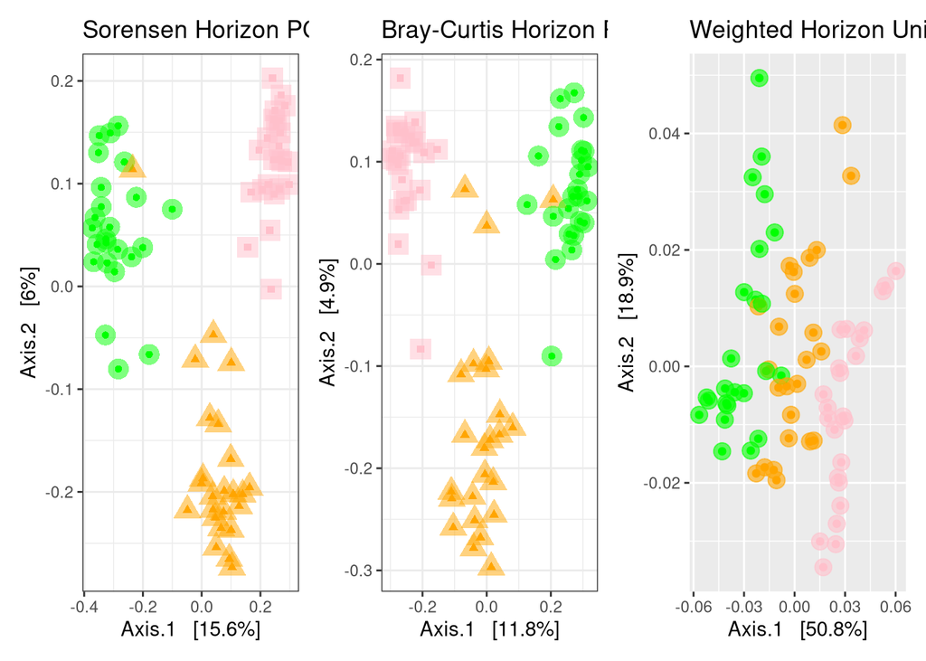

```r
#combine the plots for horizon
(soren_horizon_pcoa + theme(legend.position = "none")) +
  (bray_horizon_pcoa + theme(legend.position = "none")) +
    (w_unifrac + theme(legend.position = "none"))
```

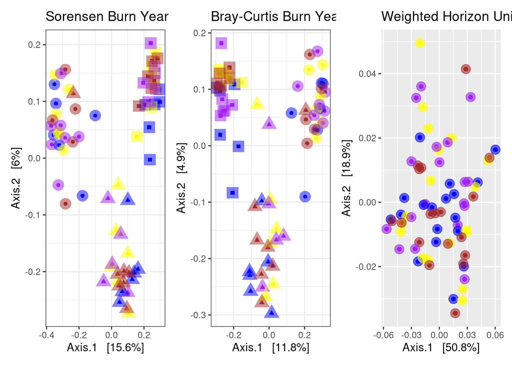

```r
#combine the plots for burn year
(soren_burnyear_pcoa + theme(legend.position = "none")) +
  (bray_burnyear_pcoa + theme(legend.position = "none")) +
    (w_unifrac_burnyear + theme(legend.position = "none"))
```

species found in individual soil horizons seem to cluster together by sorensen Since I have incorporated both burn year and horizons, it seems that samples cluster together based on the soil horizon. similar results for the bc; similar clustering based on soil horizon

## NMDS

```r
scaled_wUNI_nmds <-
  ordinate(
    physeq = scaled_merged_phytree,
    method = "NMDS",
    distance = "wunifrac")
```

```
## *** Best solution repeated 2 times
```

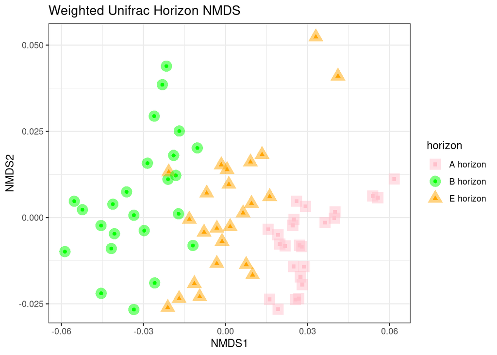

```r
#horizon nmds
wUNI_horizon_nmds <-
  plot_ordination(
    physeq = scaled_merged_phytree,
    ordination = scaled_wUNI_nmds,
    color = "horizon",
    shape = "horizon",
    title = "Weighted Unifrac Horizon NMDS") +
  geom_point(size=5, alpha = 0.5, aes(color = horizon)) +
  scale_shape_manual(values = c(15,16,17,18, 19, 20)) +
  scale_color_manual(values = c(horizon_colors)) +
  theme_bw()
wUNI_horizon_nmds
```

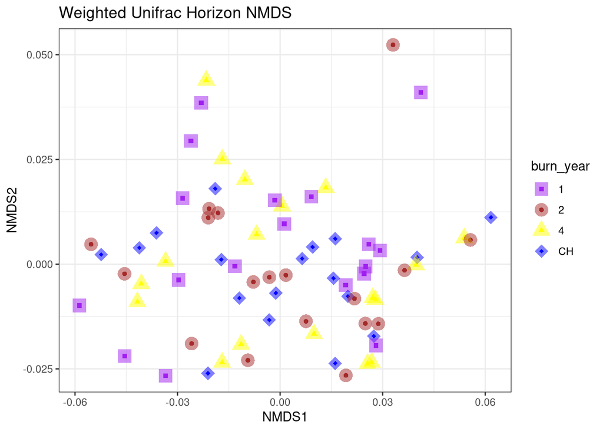

```r
#burn year nmds
wUNI_burnyear_nmds <-
  plot_ordination(
    physeq = scaled_merged_phytree,
    ordination = scaled_wUNI_nmds,
    color = "burn_year",
    shape = "burn_year",
    title = "Weighted Unifrac Horizon NMDS") +
  geom_point(size=5, alpha = 0.5, aes(color = burn_year)) +
  scale_shape_manual(values = c(15,16,17,18, 19, 20)) +
  scale_color_manual(values = c(by_colors)) +
  theme_bw()
wUNI_burnyear_nmds
```

There isn’t a strong correlation with burn year, which completely goes against the hypothesis. Data points cluster more based on horizon, and this can be observed within plots colored by horizon as datapoints.

## PERMANOVA

```r
# Calculate all three of the distance matrices
scaled_sorensen_dist <- phyloseq::distance(scaled_merged_phytree, method = "bray", binary = TRUE)
scaled_bray_dist <- phyloseq::distance(scaled_merged_phytree, method = "bray")
scaled_wUnifrac_dist <- phyloseq::distance(scaled_merged_phytree, method = "wunifrac")

# make a data frame from the sample_data
# All distance matrices will be the same metadata because they originate from the same phyloseq object.
metadata_horizon <- data.frame(sample_data(scaled_merged_phytree))

# Adonis test for horizon
adonis2(scaled_sorensen_dist ~ horizon, data = metadata_horizon)
```

```
## Permutation test for adonis under reduced model
## Terms added sequentially (first to last)
## Permutation: free
## Number of permutations: 999
##
## adonis2(formula = scaled_sorensen_dist ~ horizon, data = metadata_horizon)
##          Df SumOfSqs      R2      F Pr(>F)
## horizon   2   4.9085 0.19621 8.4219  0.001 ***
## Residual 69  20.1075 0.80379
## Total    71  25.0160 1.00000
## ---
## Signif. codes:  0 '***' 0.001 '**' 0.01 '*' 0.05 '.' 0.1 ' ' 1
```

```r
adonis2(scaled_bray_dist ~ horizon, data=metadata_horizon)
```

```
## Permutation test for adonis under reduced model
## Terms added sequentially (first to last)
## Permutation: free
## Number of permutations: 999
##
## adonis2(formula = scaled_bray_dist ~ horizon, data = metadata_horizon)
##          Df SumOfSqs      R2      F Pr(>F)
## horizon   2   4.2403 0.15225 6.1959  0.001 ***
## Residual 69  23.6107 0.84775
## Total    71  27.8509 1.00000
## ---
## Signif. codes:  0 '***' 0.001 '**' 0.01 '*' 0.05 '.' 0.1 ' ' 1
```

```r
adonis2(scaled_wUnifrac_dist ~ horizon, data=metadata_horizon)
```

```
## Permutation test for adonis under reduced model
## Terms added sequentially (first to last)
## Permutation: free
## Number of permutations: 999
##
## adonis2(formula = scaled_wUnifrac_dist ~ horizon, data = metadata_horizon)
##          Df SumOfSqs      R2      F Pr(>F)
## horizon   2 0.053975 0.48939 33.066  0.001 ***
## Residual 69 0.056315 0.51061
## Total    71 0.110290 1.00000
## ---
## Signif. codes:  0 '***' 0.001 '**' 0.01 '*' 0.05 '.' 0.1 ' ' 1
```

```r
metadata_horizon <- data.frame(sample_data(scaled_merged_phytree))

# Adonis test for burn year
metadata_burnyear <- data.frame(sample_data(scaled_merged_phytree))

adonis2(scaled_sorensen_dist ~ burn_year, data = metadata_burnyear)
```

```
## Permutation test for adonis under reduced model
## Terms added sequentially (first to last)
## Permutation: free
## Number of permutations: 999
##
## adonis2(formula = scaled_sorensen_dist ~ burn_year, data = metadata_burnyear)
##           Df SumOfSqs      R2      F Pr(>F)
## burn_year  3   1.0674 0.04267 1.0103  0.377
## Residual  68  23.9485 0.95733
## Total     71  25.0160 1.00000
```

```r
adonis2(scaled_bray_dist ~ burn_year, data=metadata_burnyear)
```

```
## Permutation test for adonis under reduced model
## Terms added sequentially (first to last)
## Permutation: free
## Number of permutations: 999
##
## adonis2(formula = scaled_bray_dist ~ burn_year, data = metadata_burnyear)
##           Df SumOfSqs      R2      F Pr(>F)
## burn_year  3   1.1949 0.04291 1.0161  0.358
## Residual  68  26.6560 0.95709
## Total     71  27.8509 1.00000
```

```r
adonis2(scaled_wUnifrac_dist ~ burn_year, data=metadata_burnyear)
```

```
## Permutation test for adonis under reduced model
## Terms added sequentially (first to last)
## Permutation: free
## Number of permutations: 999
##
## adonis2(formula = scaled_wUnifrac_dist ~ burn_year, data = metadata_burnyear)
##           Df SumOfSqs      R2     F Pr(>F)
## burn_year  3 0.003134 0.02842 0.663  0.781
## Residual  68 0.107156 0.97158
## Total     71 0.110290 1.00000
```

```r
metadata_burnyear <- data.frame(sample_data(scaled_merged_phytree))
```

Most variation is explained in the weighted unifrac for horizon (almost 0.50 Rvalue), and has the highest F statistic, showing greater differences between samples due to horizon.

## Running betadispr

```r
#this will tell how sensitive the permanova was to variance in the data
beta_soren_horizon <- betadisper(scaled_sorensen_dist, metadata_horizon$horizon)
permutest(beta_soren_horizon)
```

```
##
## Permutation test for homogeneity of multivariate dispersions
## Permutation: free
## Number of permutations: 999
##
## Response: Distances
##           Df   Sum Sq   Mean Sq      F N.Perm Pr(>F)
## Groups     2 0.036833 0.0184167 5.1696    999  0.005 **
## Residuals 69 0.245812 0.0035625
## ---
## Signif. codes:  0 '***' 0.001 '**' 0.01 '*' 0.05 '.' 0.1 ' ' 1
```

```r
#burn year
beta_soren_burnyear <- betadisper(scaled_sorensen_dist, metadata_burnyear$burn_year)
permutest(beta_soren_burnyear)
```

```
##
## Permutation test for homogeneity of multivariate dispersions
## Permutation: free
## Number of permutations: 999
##
## Response: Distances
##           Df   Sum Sq   Mean Sq      F N.Perm Pr(>F)
## Groups     3 0.009186 0.0030619 0.9542    999   0.42
## Residuals 68 0.218195 0.0032087
```

## Phylum Composition

```r
# Set the phylum colors

phylum_colors <- c(
  Acidobacteriota = "navy",
  Actinobacteriota = "darkslategray2",
  Chloroflexi= "cyan",
  Crenarchaeota = "firebrick",
"WPS-2" = "magenta",
 Verrucomicrobiota = "#3E9B96",
  Desulfobacterota = "greenyellow",
 Nitrospirota = "yellow",
  Planctomycetota = "#B5D6AA",
  Proteobacteria = "palevioletred1",
  "RCP2-54" = "royalblue",
  Thermoplasmatota = "darkorange",
  Firmicutes = "olivedrab",
  GAL15 = "greenyellow",
  Gemmatimonadota = "green",
  Myxococcota = "darkorchid1",
 Other = "grey")
```

## Phylum barplots

```r
# get sample data in df
sample_data_df <- data.frame(scaled_merged_phytree@sam_data)

# add reps
modified_sample_data <- sample_data_df %>%
  group_by(burn_year, horizon) %>%
  mutate(replicate_number = row_number())


# fix row names for merge back into phyloseq object
rownames(modified_sample_data) <- modified_sample_data$names
```

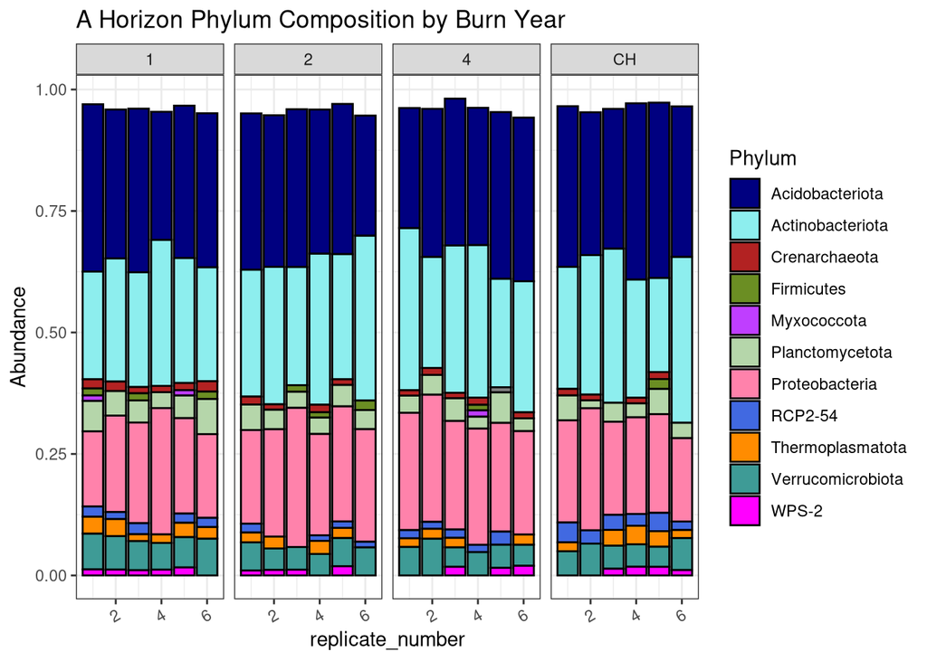

```r
new_sample_data <- sample_data(modified_sample_data)

rownames(new_sample_data) <- modified_sample_data$names

view(new_sample_data)

# merge back into phyloseq

phyloseq_with_reps <- merge_phyloseq(scaled_merged_phytree@otu_table,
                 scaled_merged_phytree@tax_table,
                 scaled_merged_phytree@phy_tree,
                 new_sample_data)
#view(phyloseq_with_reps@sam_data)

phylum_df <-
  phyloseq_with_reps %>%
  # agglomerate at the phylum level
  tax_glom(taxrank = "Phylum") %>%
  # Transform counts to relative abundance
  transform_sample_counts(function (x) {x/sum(x)}) %>%
  # Melt to a long format
  psmelt() %>%
  # Filter out Phyla that are <1% - get rid of low abundant Phyla
  dplyr::filter(Abundance > 0.01)

view(phyloseq_with_reps@sam_data)
#I am going to see the unique phyla in the tax df
#phyla <- unique(phylum_df$Phylum)
#view(phyla)



# Stacked Bar Plot With All phyla
# Plot Phylum Abundances - make sure to load phylum_colors
phylum_df %>%
  # Warning: It's important to have one sample per x value,
  # otherwise, it will take the sum between multiple samples

 #must separate by horizon so that barplots are not stacking on top of each other
  dplyr::filter(horizon=="A horizon") %>%
  ggplot(aes(x = replicate_number, y = Abundance, fill = Phylum)) +
  facet_grid(.~burn_year) +
  geom_bar(stat = "identity", color = "black") +
  labs(title = "A Horizon Phylum Composition by Burn Year") +
  scale_fill_manual(values = phylum_colors) +
  theme_bw() +
  theme(axis.text.x = element_text(angle = 30, hjust = 1, vjust = 1))
```

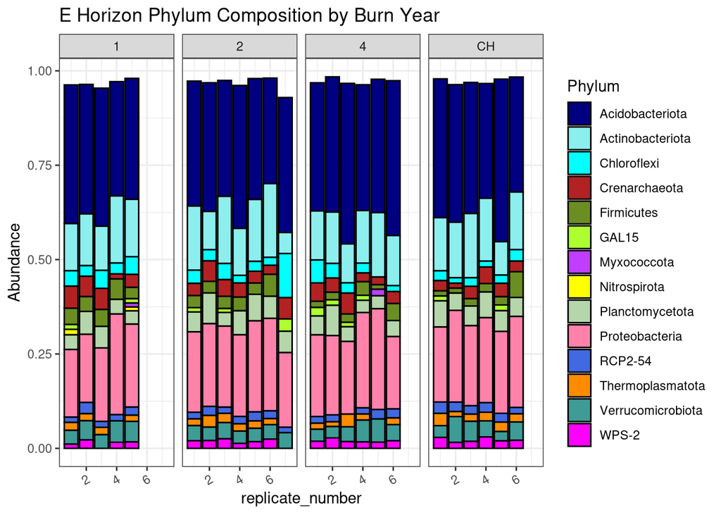

```r
phylum_df %>%
  dplyr::filter(horizon=="E horizon") %>%
  ggplot(aes(x = replicate_number, y = Abundance, fill = Phylum)) +
  facet_grid(.~burn_year) +
  geom_bar(stat = "identity", color = "black") +
  labs(title = "E Horizon Phylum Composition by Burn Year") +
  scale_fill_manual(values = phylum_colors) +
  theme_bw() +
  theme(axis.text.x = element_text(angle = 30, hjust = 1, vjust = 1))
```

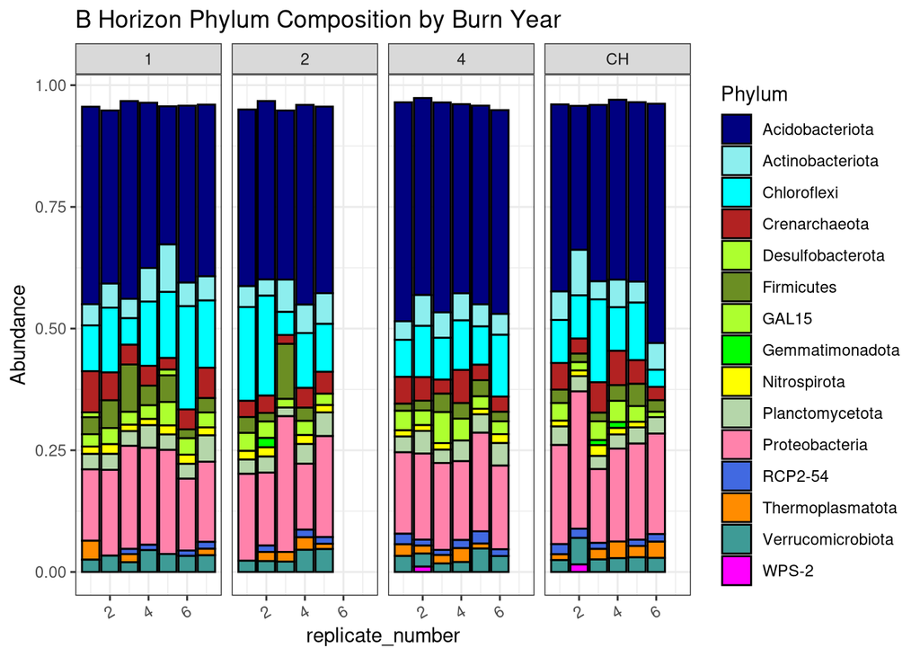

```r
phylum_df %>%
  dplyr::filter(horizon=="B horizon") %>%
  ggplot(aes(x = replicate_number, y = Abundance, fill = Phylum)) +
  facet_grid(.~burn_year) +
  geom_bar(stat = "identity", color = "black") +
  labs(title = "B Horizon Phylum Composition by Burn Year") +
  scale_fill_manual(values = phylum_colors) +
  theme_bw() +
  theme(axis.text.x = element_text(angle = 30, hjust = 1, vjust = 1))
```

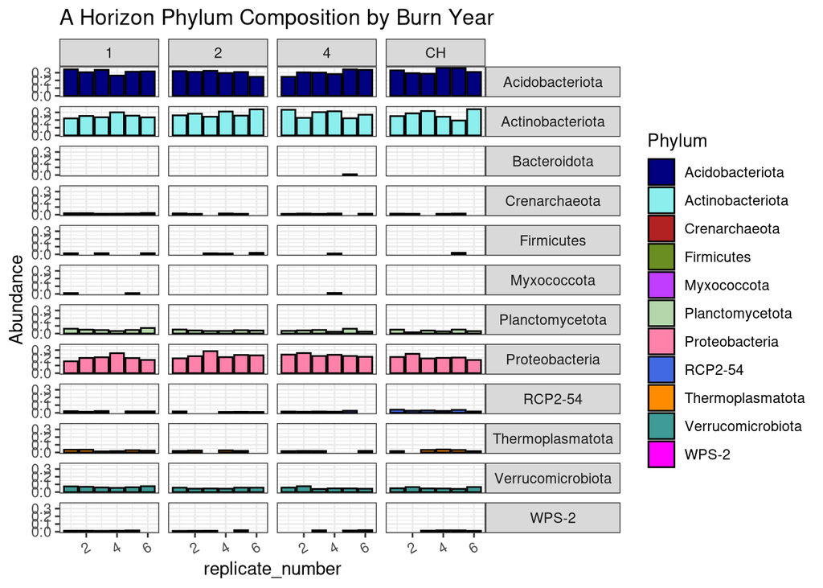

```r
#make each phylum its own row
#a horizon
phylum_df %>%
  dplyr::filter(horizon=="A horizon") %>%
  ggplot(aes(x = replicate_number, y = Abundance, fill = Phylum)) +
  facet_grid(Phylum~burn_year) +
  geom_bar(stat = "identity", color = "black") +
  labs(title = "A Horizon Phylum Composition by Burn Year") +
  scale_fill_manual(values = phylum_colors) +
  theme_bw() +
  theme(axis.text.x = element_text(angle = 30, hjust = 1, vjust = 1), strip.text.y.right = element_text(angle = 0))
```

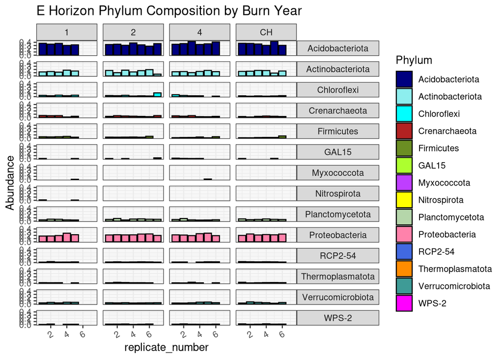

```r
#e horizon
phylum_df %>%
  dplyr::filter(horizon=="E horizon") %>%
  ggplot(aes(x = replicate_number, y = Abundance, fill = Phylum)) +
  facet_grid(Phylum~burn_year) +
  geom_bar(stat = "identity", color = "black") +
  labs(title = "E Horizon Phylum Composition by Burn Year") +
  scale_fill_manual(values = phylum_colors) +
  theme_bw() +
  theme(axis.text.x = element_text(angle = 30, hjust = 1, vjust = 1), strip.text.y.right = element_text(angle = 0))
```

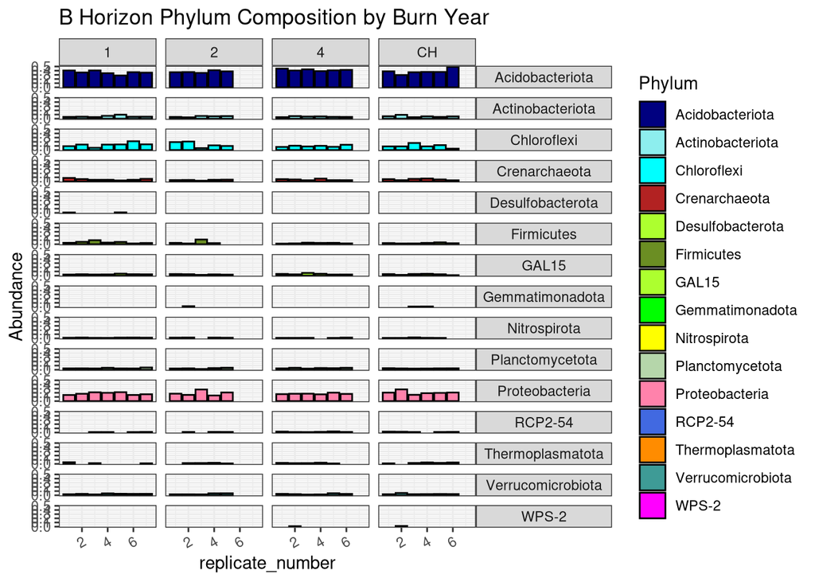

```r
#b horizon
phylum_df %>%
  dplyr::filter(horizon=="B horizon") %>%
  ggplot(aes(x = replicate_number, y = Abundance, fill = Phylum)) +
  facet_grid(Phylum~burn_year) +
  geom_bar(stat = "identity", color = "black") +
  labs(title = "B Horizon Phylum Composition by Burn Year") +
  scale_fill_manual(values = phylum_colors) +
  theme_bw() +
  theme(axis.text.x = element_text(angle = 30, hjust = 1, vjust = 1), strip.text.y.right = element_text(angle = 0))
```

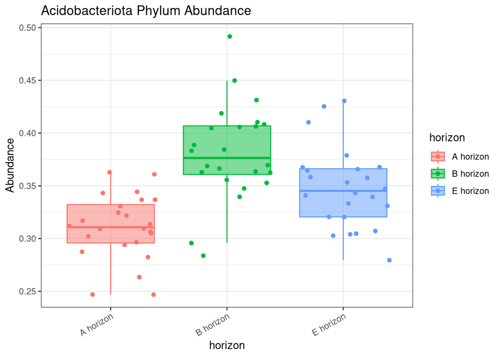

```r
#look at a specific phylum
phylum_df %>%
  dplyr::filter(Phylum == "Acidobacteriota") %>%
  # build the plot
  ggplot(aes(x = horizon, y = Abundance,
             fill = horizon, color = horizon)) +
  geom_boxplot(alpha = 0.5, outlier.shape = NA) + # outliers not plotted here in boxplot
  geom_jitter() +
  theme_bw() +
  labs(title = "Acidobacteriota Phylum Abundance") +
  #scale_color_manual(values = by_colors) +
  #scale_fill_manual(values = by_colors) +
    theme(axis.text.x = element_text(angle = 30, hjust = 1, vjust = 1),
          legend.position = "right")
```

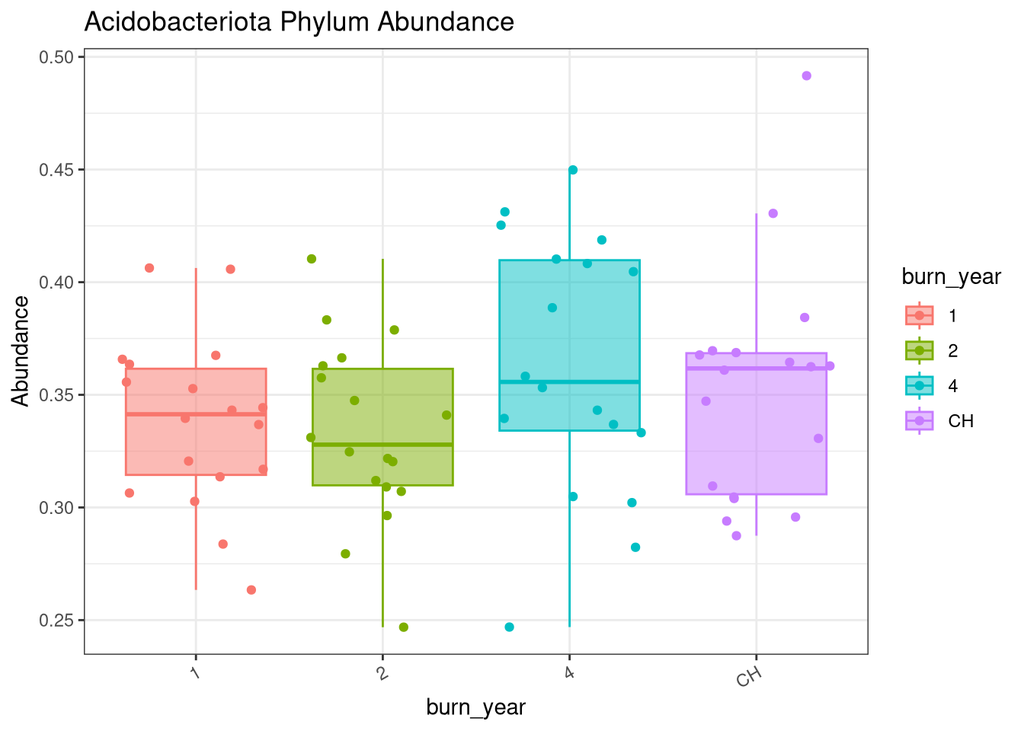

```r
#look at a specific phylum
phylum_df %>%
  dplyr::filter(Phylum == "Acidobacteriota") %>%
  # build the plot
  ggplot(aes(x = burn_year, y = Abundance,
             fill = burn_year, color = burn_year)) +
  geom_boxplot(alpha = 0.5, outlier.shape = NA) + # outliers not plotted here in boxplot
  geom_jitter() +
  theme_bw() +
  labs(title = "Acidobacteriota Phylum Abundance") +
  #scale_color_manual(values = by_colors) +
  #scale_fill_manual(values = by_colors) +
    theme(axis.text.x = element_text(angle = 30, hjust = 1, vjust = 1),
          legend.position = "right")
```

Acidobacteriodota seems to have a higher composition at lower horizons, but I can only tell this from the bar plots. These bacteria are typically found in hot springs so it is interesting seeing it appear.

# Do the same thing for family and genus

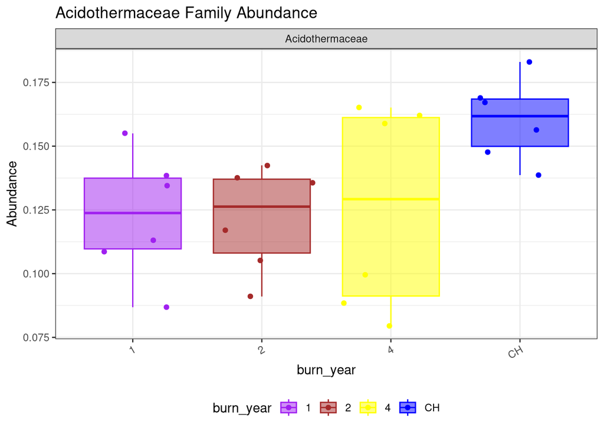

```r
family_df <-
  phyloseq_with_reps %>%
  # agglomerate at the phylum level
  tax_glom(taxrank = "Family") %>%
  # Transform counts to relative abundance
  transform_sample_counts(function (x) {x/sum(x)}) %>%
  # Melt to a long format
  psmelt() %>%
  # Filter out Phyla that are <1% - get rid of low abundant Phyla
  dplyr::filter(Abundance > 0.01)

view(phyloseq_with_reps@sam_data)


family_df %>%
 #must separate by horizon so that barplots are not stacking on top of each other
  dplyr::filter(horizon=="A horizon") %>%
  dplyr::filter(Family == "Acidothermaceae") %>%
 ggplot(aes(x = burn_year, y = Abundance,
             fill = burn_year, color = burn_year)) +
  facet_wrap(.~Family, scales = "fixed", nrow = 1) +
  geom_boxplot(alpha = 0.5, outlier.shape = NA) + # outliers not plotted here in boxplot
  geom_jitter() +
  theme_bw() +
  labs(title = "Acidothermaceae Family Abundance") +
  scale_color_manual(values = by_colors) +
  scale_fill_manual(values = by_colors) +
  theme(axis.text.x = element_text(angle = 30, hjust = 1, vjust = 1),
        legend.position = "bottom")
```

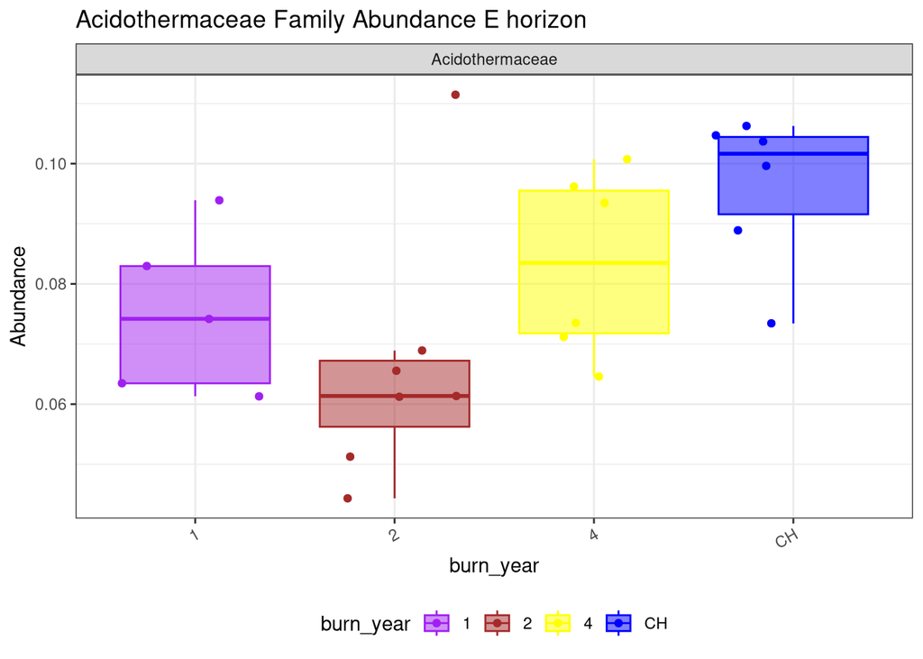

```r
family_df %>%
 #must separate by horizon so that barplots are not stacking on top of each other
  dplyr::filter(horizon=="E horizon") %>%
  dplyr::filter(Family == "Acidothermaceae") %>%
 ggplot(aes(x = burn_year, y = Abundance,
             fill = burn_year, color = burn_year)) +
  facet_wrap(.~Family, scales = "fixed", nrow = 1) +
  geom_boxplot(alpha = 0.5, outlier.shape = NA) + # outliers not plotted here in boxplot
  geom_jitter() +
  theme_bw() +
  labs(title = "Acidothermaceae Family Abundance E horizon") +
  scale_color_manual(values = by_colors) +
  scale_fill_manual(values = by_colors) +
  theme(axis.text.x = element_text(angle = 30, hjust = 1, vjust = 1),
        legend.position = "bottom")
```

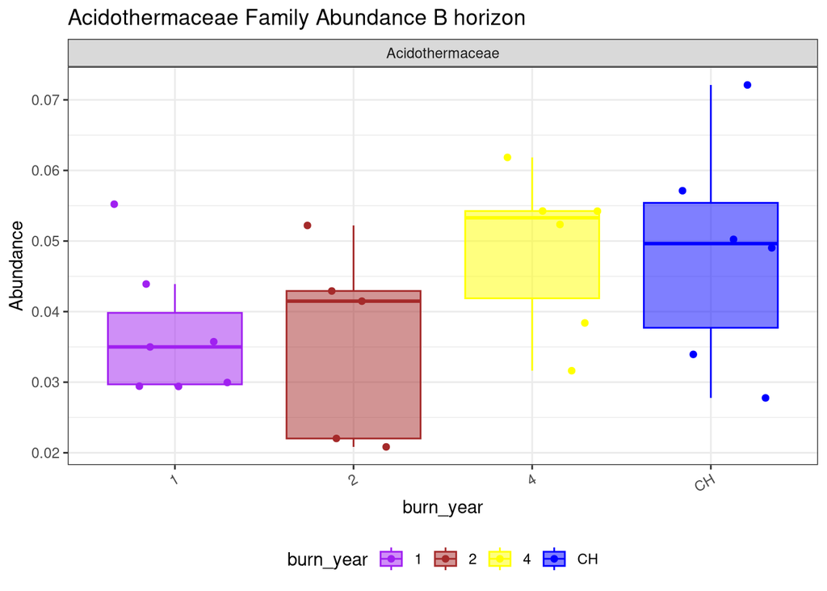

```r
family_df %>%
 #must separate by horizon so that barplots are not stacking on top of each other
  dplyr::filter(horizon=="B horizon") %>%
  dplyr::filter(Family == "Acidothermaceae") %>%
 ggplot(aes(x = burn_year, y = Abundance,
             fill = burn_year, color = burn_year)) +
  facet_wrap(.~Family, scales = "fixed", nrow = 1) +
  geom_boxplot(alpha = 0.5, outlier.shape = NA) + # outliers not plotted here in boxplot
  geom_jitter() +
  theme_bw() +
  labs(title = "Acidothermaceae Family Abundance B horizon") +
  scale_color_manual(values = by_colors) +
  scale_fill_manual(values = by_colors) +
  theme(axis.text.x = element_text(angle = 30, hjust = 1, vjust = 1),
        legend.position = "bottom")
```

Acidothermacaea decreases at the E horizon (scales changed), which I thought would be the opposite due to the previous graph. Abundance decreased further in the B horizon.

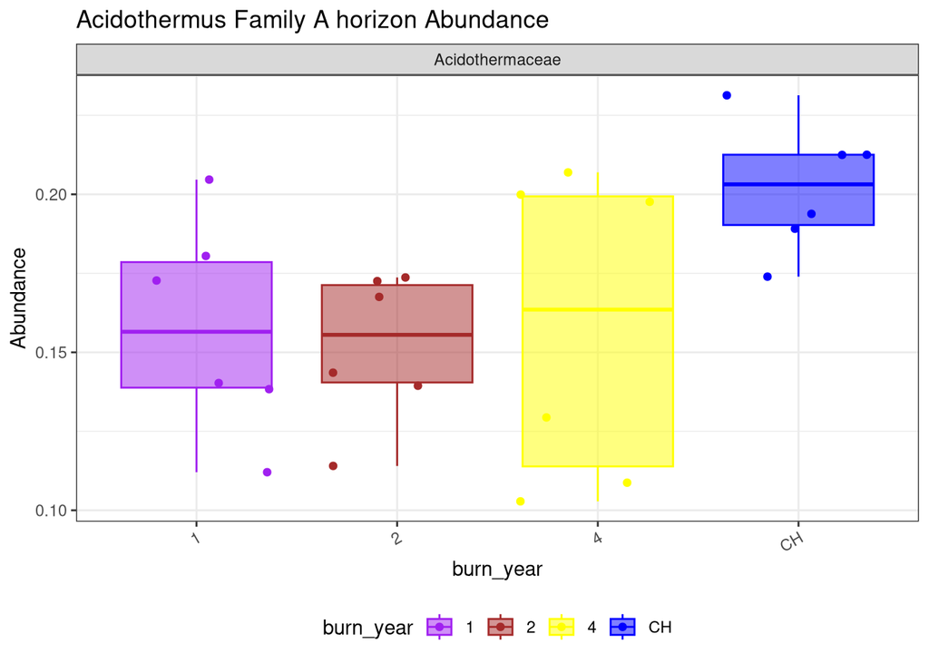

```r
genus_df <-
  phyloseq_with_reps %>%
  # agglomerate at the phylum level
  tax_glom(taxrank = "Genus") %>%
  # Transform counts to relative abundance
  transform_sample_counts(function (x) {x/sum(x)}) %>%
  # Melt to a long format
  psmelt() %>%
  # Filter out Phyla that are <1% - get rid of low abundant Phyla
  dplyr::filter(Abundance > 0.01)

view(phyloseq_with_reps@sam_data)


genus_df %>%
 #must separate by horizon so that barplots are not stacking on top of each other
  dplyr::filter(horizon=="A horizon") %>%
  dplyr::filter(Genus == "Acidothermus") %>%
 ggplot(aes(x = burn_year, y = Abundance,
             fill = burn_year, color = burn_year)) +
  facet_wrap(.~Family, scales = "fixed", nrow = 1) +
  geom_boxplot(alpha = 0.5, outlier.shape = NA) + # outliers not plotted here in boxplot
  geom_jitter() +
  theme_bw() +
  labs(title = "Acidothermus Family A horizon Abundance") +
 scale_color_manual(values = by_colors) +
  scale_fill_manual(values = by_colors) +
  theme(axis.text.x = element_text(angle = 30, hjust = 1, vjust = 1),
        legend.position = "bottom")
```

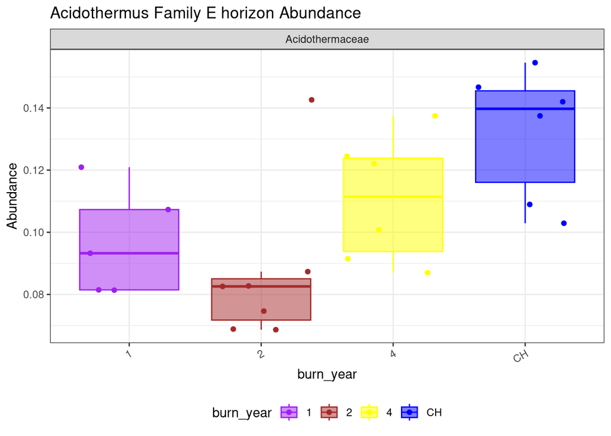

```r
genus_df %>%
 #must separate by horizon so that barplots are not stacking on top of each other
  dplyr::filter(horizon=="E horizon") %>%
  dplyr::filter(Genus == "Acidothermus") %>%
 ggplot(aes(x = burn_year, y = Abundance,
             fill = burn_year, color = burn_year)) +
  facet_wrap(.~Family, scales = "fixed", nrow = 1) +
  geom_boxplot(alpha = 0.5, outlier.shape = NA) + # outliers not plotted here in boxplot
  geom_jitter() +
  theme_bw() +
  labs(title = "Acidothermus Family E horizon Abundance") +
  scale_color_manual(values = by_colors) +
  scale_fill_manual(values = by_colors) +
  theme(axis.text.x = element_text(angle = 30, hjust = 1, vjust = 1),
        legend.position = "bottom")
```

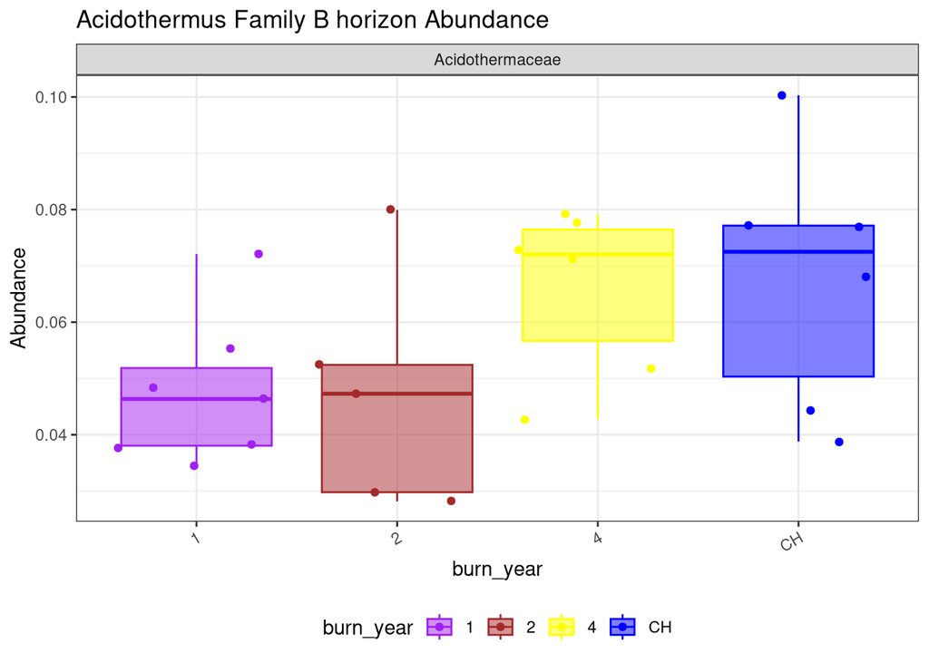

```r
genus_df %>%
 #must separate by horizon so that barplots are not stacking on top of each other
  dplyr::filter(horizon=="B horizon") %>%
  dplyr::filter(Genus == "Acidothermus") %>%
 ggplot(aes(x = burn_year, y = Abundance,
             fill = burn_year, color = burn_year)) +
  facet_wrap(.~Family, scales = "fixed", nrow = 1) +
  geom_boxplot(alpha = 0.5, outlier.shape = NA) + # outliers not plotted here in boxplot
  geom_jitter() +
  theme_bw() +
  labs(title = "Acidothermus Family B horizon Abundance") +
  scale_color_manual(values = by_colors) +
  scale_fill_manual(values = by_colors) +
  theme(axis.text.x = element_text(angle = 30, hjust = 1, vjust = 1),
        legend.position = "bottom")
```